# Data Wrangling and Analysis via Twitter

**Objective:** Wrangle WeRateDogs Twitter data to create interesting and trustworthy analyses and visualizations.

Accomplish the following:

- Gather data from 3 different sources and formats.
- Identify and clean 8 quality (content) issues.
- Identify and clean 2 tidiness (structure) issues.
- Analyze data by producing 3 insights and 1 visualization.
- Introduction
- Gather
- Assess
- Clean
- Analyze

## Introduction

**Dogtionary:** There are various stages of dog, which will be part of the observed data: doggo, pupper, puppo, and floof(er).

**Data Information:**

*Twitter Archive*

The WeRateDogs Twitter archive is a file called `twitter-archive-enhanced.csv` that contains basic tweet data for all 5000+ of their tweets. The Twitter archive data has been filtered for tweets with ratings only, bringing the total record count to 2356.

*Twitter API*

Additional data can be gathered by anyone using the Twitter API. This queried data is stored in a file called `tweet_json.txt`. This shows data on retweet count and favorite count.

*Image Predictions*

Using a neural network, images classified dogs by breed. This is hosted on Udacity's servers and should be downloaded programmatically using the Requests library and the following URL: https://d17h27t6h515a5.cloudfront.net/topher/2017/August/599fd2ad_image-predictions/image-predictions.tsv

```python
# import all libraries

# Data analysis
import pandas as pd
import numpy as np

# Visualization
import matplotlib.pyplot as plt
import seaborn as sns
%matplotlib inline
```

## Analyze

My insights for this dataset will be regarding these 2 questions:

1. What is the average rating and popularity by dog breed?
2. What is the average rating and popularity by dog stage?

### Insights for dog breeds

```python
avg_rating_breed = pd.DataFrame(df.groupby('dog_breed').mean().rating_numerator).sort_values('rating_numerator')
avg_rating_breed.describe()
```

|  | rating_numerator |
| --- | --- |
| count | 113.000000 |
| mean | 10.637943 |
| std | 0.953541 |
| min | 5.000000 |
| 25% | 10.133333 |
| 50% | 10.650000 |
| 75% | 11.250000 |
| max | 13.000000 |

```python
# Which dog has the highest average rating?
avg_rating_breed[avg_rating_breed.rating_numerator == avg_rating_breed.rating_numerator.max()]
```

| dog_breed | rating_numerator |
| --- | --- |
| bouvier_des_flandres | 13.0 |

```python
# Which dog has the lowest average rating?
avg_rating_breed[avg_rating_breed.rating_numerator == avg_rating_breed.rating_numerator.min()]
```

| dog_breed | rating_numerator |
| --- | --- |
| japanese_spaniel | 5.0 |

Out of the 113 breeds identified, the average rating out of 10 is 10.64. The highest average is 13.00 which belongs to the bouvier des flandres (I had to Google this breed). The lowest average is 5.00 which belongs to the Japanese spaniel.

Since there are a lot of breeds with many rare or uncommon ones, I will filter the dataset for less dog breeds using a tweet count threshold.

```python
# Count the number of tweets for each dog breed
count_rating_breed = pd.DataFrame(df.groupby('dog_breed').count().tweet_id).sort_values('tweet_id')
count_rating_breed.describe()
```

|  | tweet_id |
| --- | --- |
| count | 113.000000 |
| mean | 15.380531 |
| std | 23.571820 |
| min | 1.000000 |
| 25% | 4.000000 |
| 50% | 8.000000 |
| 75% | 16.000000 |
| max | 173.000000 |

```
array([[<matplotlib.axes._subplots.AxesSubplot object at 0x136deae10>]],
      dtype=object)
```

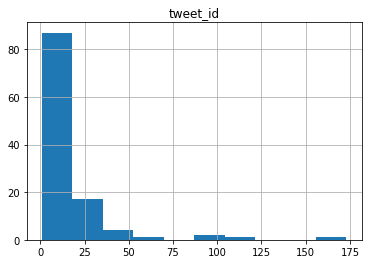

```python
# Plot distribution
count_rating_breed.hist()
```

Out of the 113 breeds, the average count of tweets is 15. The distribution of tweet counts by dog breeds is heavily skewed right, with 25% of the breeds (28 breeds) having less than 4 tweets. If I eliminate dog breeds that have under 16 tweets, I will only get the top quartile with ~28 more common breeds to observe.

```python
# Get list of dog breeds with 16 or more tweets
dog_breeds = pd.DataFrame(count_rating_breed[count_rating_breed.tweet_id >= 16].reset_index().dog_breed)

# Filter dataframe
df_filtered_breeds = df.merge(dog_breeds, how="inner", on="dog_breed")

# Get distribution of ratings for these popular dog breeds
pd.DataFrame(df_filtered_breeds.groupby('dog_breed').mean().rating_numerator).sort_values('rating_numerator').describe()
```

|  | rating_numerator |
| --- | --- |
| count | 29.000000 |
| mean | 10.837274 |
| std | 0.543282 |
| min | 9.526316 |
| 25% | 10.526316 |
| 50% | 10.882353 |
| 75% | 11.173913 |
| max | 11.755556 |

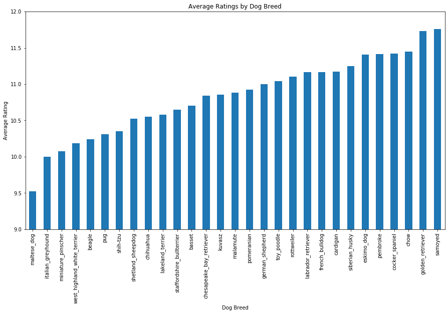

```python
# Plot ratings
fig = plt.figure(figsize=(15,8))
df_filtered_breeds.groupby("dog_breed").mean().sort_values('rating_numerator').rating_numerator.plot(kind="bar")
plt.title("Average Ratings by Dog Breed")
plt.ylabel("Average Rating")
plt.xlabel("Dog Breed")
plt.ylim(9,12);
```

Samoyed is the dog with highest ratings among the 29 popular dog breeds with at least 16 tweets. Golder retriever is a close second. The maltese dog is less popular with an average rating below 10.

Besides average rating, I will check if average rating has correlation with retweet count or favorite count.

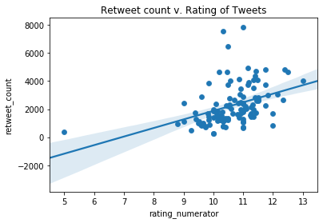

```python
stats_by_breed = df.groupby('dog_breed').mean()[["rating_numerator","favorite_count","retweet_count"]]

# Plot rating by retweet count
stats_by_breed.plot(x='rating_numerator', y='retweet_count', kind='scatter')
sns.regplot(stats_by_breed['rating_numerator'], stats_by_breed['retweet_count'])
plt.title('Retweet count v. Rating of Tweets')
```

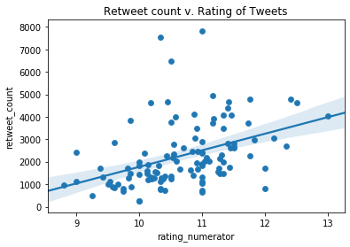

```python
# Ignore the 5 rating because it's an outlier
stats_by_breed = stats_by_breed.query('rating_numerator > 5')

stats_by_breed.plot(x='rating_numerator', y='retweet_count', kind='scatter')
sns.regplot(stats_by_breed['rating_numerator'], stats_by_breed['retweet_count'])
plt.title('Retweet count v. Rating of Tweets')
```

The positive slope indicates there's a correlation between rating and retweet.

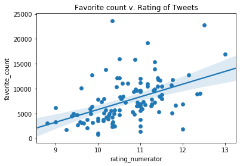

```python
# Plot rating by favorite count
stats_by_breed.plot(x='rating_numerator', y='favorite_count', kind='scatter')
sns.regplot(stats_by_breed['rating_numerator'], stats_by_breed['favorite_count'])
plt.title('Favorite count v. Rating of Tweets')
```

There's also a positive correlation with rating and favorite count.

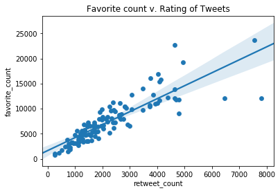

```python
# Plot retweet by favorite count
stats_by_breed.plot(x='retweet_count', y='favorite_count', kind='scatter')
sns.regplot(stats_by_breed['retweet_count'], stats_by_breed['favorite_count'])
plt.title('Favorite count v. Rating of Tweets')
```

There's a very strong correlation between favorite and retweet count. This might be expected because the more views or actions on a tweet could cause both retweets and favorites. People who tend to favorite might also share this with friends.

I can probably guess that for dog breeds, the types with higher favorite counts would also have higher retweet counts.

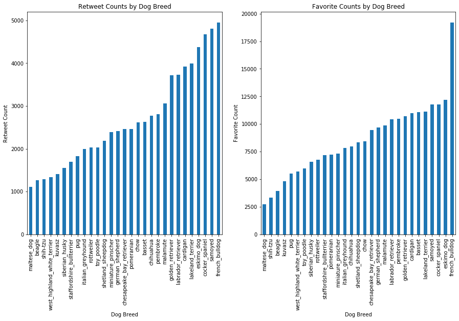

```python
plt.figure(figsize=(15,8))

plt.subplot(121)
df_filtered_breeds.groupby("dog_breed").mean().sort_values('retweet_count').retweet_count.plot(kind="bar")
plt.title("Retweet Counts by Dog Breed")
plt.ylabel("Retweet Count")
plt.xlabel("Dog Breed")

plt.subplot(122)
df_filtered_breeds.groupby("dog_breed").mean().sort_values('favorite_count').favorite_count.plot(kind="bar")
plt.title("Favorite Counts by Dog Breed")
plt.ylabel("Favorite Count")
plt.xlabel("Dog Breed")
```

The highest retweet and favorite count belongs to the french bulldog. The maltese dog, shi tzu, and beagle are in the bottom 3 for both retweet and favorite counts.

### Insights for Dog Stage

```python
# Filter out tweets with no dog stage classification
df_doggo_filtered = df_doggo[~df_doggo.dog_stage.isnull()]

df_doggo_filtered.shape[0]
```

```
332
```

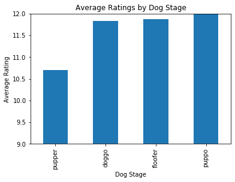

```python
# Plot ratings
df_doggo_filtered.groupby("dog_stage").mean().sort_values('rating_numerator').rating_numerator.plot(kind="bar")
plt.title("Average Ratings by Dog Stage")
plt.ylabel("Average Rating")
plt.xlabel("Dog Stage")
plt.ylim(9,12);
```

Puppo has the highest average rating followed by floofer then doggo. Pupper has the lowest average rating.

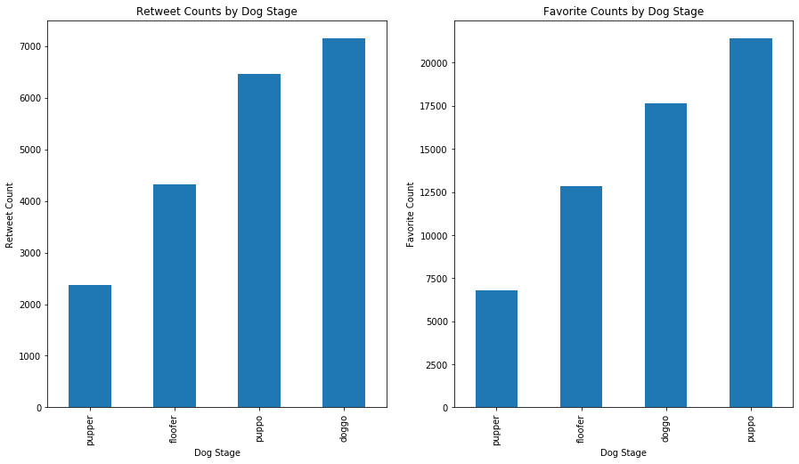

```python
plt.figure(figsize=(15,8))

plt.subplot(121)
df_doggo_filtered.groupby("dog_stage").mean().sort_values('retweet_count').retweet_count.plot(kind="bar")
plt.title("Retweet Counts by Dog Stage")
plt.ylabel("Retweet Count")
plt.xlabel("Dog Stage")

plt.subplot(122)
df_doggo_filtered.groupby("dog_stage").mean().sort_values('favorite_count').favorite_count.plot(kind="bar")
plt.title("Favorite Counts by Dog Stage")
plt.ylabel("Favorite Count")
plt.xlabel("Dog Stage")
```

Similar to the previous analysis on average rating, pupper has the lowest retweet and favorite count. Doggo and puppo share the first 2 highest counts.